# F9_03_PROG_REV

Program service accomplishment revenue · Amount report

## Overview

**Description**

Program Accomplishment Revenue

**Table**

**Location code**

`F990-PC-PART-03-LINE-04-ABCD`

**Family**

`F990-PC-PART-03-LINE-04-ABCD` · siblings: F9_03_PROG_CODE, F9_03_PROG_DESC, F9_03_PROG_EXP, F9_03_PROG_GRANT, F9_03_PROG_EXP_OTH_TOT, F9_03_PROG_GRANT_OTH_TOT

**Data type**

numeric (xsd: USAmountType, )

**Scope**

PC

**Status**

unreviewed

12

xpaths mapped (8 observed)

3,094,415

filings with a value

2009–2024

tax years observed

10

open flags (1 errors)

## Flags

[output not shown]

## Xpaths

All mapped xpaths (under /Return/ReturnData or /Return/ReturnHeader), oldest first. Charts label each series by its xpath.

| Xpath | Form | Chart label | First year | Last year | Versions | Filings | Repeats in |
| --- | --- | --- | --- | --- | --- | --- | --- |
| IRS990/Revenue | 990 | same | 2009 | 2012 | 18 | 250,352 | 0.0% |
| IRS990/Activity2/Revenue | 990 | same | 2009 | 2012 | 18 | 75,754 | 0.0% |
| IRS990/Activity3/Revenue | 990 | same | 2009 | 2012 | 18 | 53,499 | 0.0% |
| IRS990/ActivityOther/Revenue | 990 | same | 2009 | 2012 | 16 | 28,532 | 20.8% |
| IRS990/RevenueAmt | 990 | same | 2013 | 2024 | 37 | 1,721,388 | 0.0% |
| IRS990/ProgSrvcAccomActy2Grp/RevenueAmt | 990 | same | 2013 | 2024 | 37 | 477,396 | 0.0% |
| IRS990/ProgSrvcAccomActy3Grp/RevenueAmt | 990 | same | 2013 | 2024 | 37 | 328,264 | 0.0% |
| IRS990/Form990PartIII/Activity2/Revenue | 990 | Other |  |  |  | 0 |  |
| IRS990/Form990PartIII/Activity3/Revenue | 990 | Other |  |  |  | 0 |  |
| IRS990/Form990PartIII/ActivityOther/Revenue | 990 | Other |  |  |  | 0 |  |
| IRS990/Form990PartIII/Revenue | 990 | Other |  |  |  | 0 |  |
| IRS990/ProgSrvcAccomActyOtherGrp/RevenueAmt | 990 | Other | 2013 | 2024 | 36 | 159,230 | 17.3% |

## Coverage

[figure not shown]

**Table view**

Table view: filings by tax year and series

| Tax year | IRS990/Revenue | IRS990/Activity2/Revenue | IRS990/Activity3/Revenue | IRS990/ActivityOther/Revenue | IRS990/RevenueAmt | IRS990/ProgSrvcAccomActy2Grp/RevenueAmt | IRS990/ProgSrvcAccomActy3Grp/RevenueAmt | Other |
| --- | --- | --- | --- | --- | --- | --- | --- | --- |
| 2009 | 20,446 | 7,178 | 5,440 | 3,073 | 0 | 0 | 0 | 0 |
| 2010 | 62,330 | 19,060 | 13,624 | 7,144 | 0 | 0 | 0 | 0 |
| 2011 | 79,234 | 23,493 | 16,400 | 8,612 | 0 | 0 | 0 | 0 |
| 2012 | 88,342 | 26,023 | 18,035 | 9,703 | 0 | 0 | 0 | 0 |
| 2013 | 0 | 0 | 0 | 0 | 97,214 | 28,094 | 19,119 | 10,340 |
| 2014 | 0 | 0 | 0 | 0 | 106,296 | 30,297 | 20,568 | 10,880 |
| 2015 | 0 | 0 | 0 | 0 | 118,810 | 32,193 | 21,668 | 11,636 |
| 2016 | 0 | 0 | 0 | 0 | 125,084 | 33,330 | 22,433 | 11,949 |
| 2017 | 0 | 0 | 0 | 0 | 133,744 | 35,281 | 23,682 | 12,634 |
| 2018 | 0 | 0 | 0 | 0 | 142,311 | 38,087 | 25,560 | 13,329 |
| 2019 | 0 | 0 | 0 | 0 | 149,214 | 39,904 | 26,842 | 13,741 |
| 2020 | 0 | 0 | 0 | 0 | 166,537 | 46,150 | 31,842 | 14,987 |
| 2021 | 0 | 0 | 0 | 0 | 174,934 | 48,939 | 33,914 | 15,212 |
| 2022 | 0 | 0 | 0 | 0 | 181,847 | 51,456 | 36,139 | 15,732 |
| 2023 | 0 | 0 | 0 | 0 | 184,894 | 53,049 | 37,560 | 16,191 |
| 2024 | 0 | 0 | 0 | 0 | 140,503 | 40,616 | 28,937 | 12,599 |

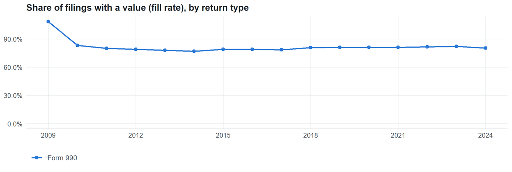

**Table view**

Table view: fill rate

| Tax year | Return type | Filings | All filings | Fill rate |
| --- | --- | --- | --- | --- |
| 2009 | Form 990 | 36,137 | 33,311 | 108.48% |
| 2010 | Form 990 | 102,158 | 123,025 | 83.04% |
| 2011 | Form 990 | 127,739 | 159,504 | 80.09% |
| 2012 | Form 990 | 142,103 | 179,688 | 79.08% |
| 2013 | Form 990 | 154,767 | 198,855 | 77.83% |
| 2014 | Form 990 | 168,041 | 218,619 | 76.86% |
| 2015 | Form 990 | 184,307 | 233,519 | 78.93% |
| 2016 | Form 990 | 192,796 | 243,903 | 79.05% |
| 2017 | Form 990 | 205,341 | 261,612 | 78.49% |
| 2018 | Form 990 | 219,287 | 271,442 | 80.79% |
| 2019 | Form 990 | 229,701 | 283,694 | 80.97% |
| 2020 | Form 990 | 259,516 | 320,342 | 81.01% |
| 2021 | Form 990 | 272,997 | 336,480 | 81.13% |
| 2022 | Form 990 | 285,171 | 349,055 | 81.70% |
| 2023 | Form 990 | 291,692 | 354,768 | 82.22% |
| 2024 | Form 990 | 222,652 | 277,298 | 80.29% |

## Repeating groups

Repeating element each xpath was observed in (from the raw indexed xpath)

| Xpath | Repeating element | Filings (summed over years) |
| --- | --- | --- |
| IRS990/Activity2/Revenue | (none) | 75754 |
| IRS990/Activity3/Revenue | (none) | 53499 |
| IRS990/ActivityOther/Revenue | (none) | 20593 |
| IRS990/ActivityOther/Revenue | IRS990/ActivityOther | 7939 |
| IRS990/Revenue | (none) | 250352 |
| IRS990/ProgSrvcAccomActy2Grp/RevenueAmt | (none) | 477396 |
| IRS990/ProgSrvcAccomActy3Grp/RevenueAmt | (none) | 328264 |
| IRS990/ProgSrvcAccomActyOtherGrp/RevenueAmt | (none) | 123422 |
| IRS990/ProgSrvcAccomActyOtherGrp/RevenueAmt | IRS990/ProgSrvcAccomActyOtherGrp | 35808 |
| IRS990/RevenueAmt | (none) | 1721388 |

## Values

[output not shown]

[figure not shown]

**Table view**

Table view: quartiles by tax year

| Series | Return | Tax year | Filings | P25 | Median | P75 |
| --- | --- | --- | --- | --- | --- | --- |
| IRS990/Revenue | 990 | 2009 | 20,446 | 207,837 | 1,290,438 | 8,448,158 |
| IRS990/Revenue | 990 | 2010 | 62,330 | 90,015 | 491,468 | 3,645,721 |
| IRS990/Revenue | 990 | 2011 | 79,234 | 88,794 | 409,964 | 2,551,186 |
| IRS990/Revenue | 990 | 2012 | 88,342 | 80,742 | 333,039 | 1,901,510 |
| IRS990/Activity2/Revenue | 990 | 2009 | 7,178 | 59,492 | 431,375 | 2,378,806 |
| IRS990/Activity2/Revenue | 990 | 2010 | 19,060 | 24,672 | 190,080 | 1,330,429 |
| IRS990/Activity2/Revenue | 990 | 2011 | 23,493 | 27,534 | 173,062 | 1,019,104 |
| IRS990/Activity2/Revenue | 990 | 2012 | 26,023 | 23,613 | 145,096 | 866,608 |
| IRS990/Activity3/Revenue | 990 | 2009 | 5,440 | 42,310 | 300,011 | 1,603,017 |
| IRS990/Activity3/Revenue | 990 | 2010 | 13,624 | 15,183 | 138,904 | 960,292 |
| IRS990/Activity3/Revenue | 990 | 2011 | 16,400 | 18,017 | 125,004 | 768,523 |
| IRS990/Activity3/Revenue | 990 | 2012 | 18,035 | 15,515 | 111,886 | 658,010 |
| IRS990/ActivityOther/Revenue | 990 | 2009 | 3,073 | 25,681 | 168,333 | 803,116 |
| IRS990/ActivityOther/Revenue | 990 | 2010 | 7,144 | 7,783 | 93,057 | 560,667 |
| IRS990/ActivityOther/Revenue | 990 | 2011 | 8,612 | 9,893 | 86,743 | 477,600 |
| IRS990/ActivityOther/Revenue | 990 | 2012 | 9,703 | 10,920 | 81,841 | 458,016 |
| IRS990/RevenueAmt | 990 | 2013 | 97,214 | 83,636 | 350,127 | 1,916,377 |
| IRS990/RevenueAmt | 990 | 2014 | 106,296 | 82,503 | 336,666 | 1,722,865 |
| IRS990/RevenueAmt | 990 | 2015 | 118,810 | 78,551 | 317,342 | 1,578,700 |
| IRS990/RevenueAmt | 990 | 2016 | 125,084 | 72,277 | 287,583 | 1,384,234 |
| IRS990/RevenueAmt | 990 | 2017 | 133,744 | 74,867 | 291,004 | 1,371,124 |
| IRS990/RevenueAmt | 990 | 2018 | 142,311 | 62,933 | 293,238 | 1,539,332 |
| IRS990/RevenueAmt | 990 | 2019 | 149,214 | 53,529 | 267,728 | 1,328,153 |
| IRS990/RevenueAmt | 990 | 2020 | 166,537 | 31,747 | 212,577 | 1,101,365 |
| IRS990/RevenueAmt | 990 | 2021 | 174,932 | 42,962 | 230,826 | 1,091,428 |
| IRS990/RevenueAmt | 990 | 2022 | 181,844 | 42,609 | 226,448 | 906,756 |
| IRS990/RevenueAmt | 990 | 2023 | 184,892 | 48,635 | 260,099 | 1,206,321 |
| IRS990/RevenueAmt | 990 | 2024 | 140,502 | 39,866 | 220,901 | 837,700 |
| IRS990/ProgSrvcAccomActy2Grp/RevenueAmt | 990 | 2013 | 28,094 | 23,011 | 141,693 | 819,490 |
| IRS990/ProgSrvcAccomActy2Grp/RevenueAmt | 990 | 2014 | 30,297 | 23,259 | 134,557 | 771,498 |
| IRS990/ProgSrvcAccomActy2Grp/RevenueAmt | 990 | 2015 | 32,193 | 21,947 | 130,604 | 730,290 |
| IRS990/ProgSrvcAccomActy2Grp/RevenueAmt | 990 | 2016 | 33,330 | 19,805 | 117,545 | 703,704 |
| IRS990/ProgSrvcAccomActy2Grp/RevenueAmt | 990 | 2017 | 35,281 | 22,931 | 125,221 | 708,596 |
| IRS990/ProgSrvcAccomActy2Grp/RevenueAmt | 990 | 2018 | 38,087 | 16,274 | 114,279 | 663,358 |
| IRS990/ProgSrvcAccomActy2Grp/RevenueAmt | 990 | 2019 | 39,904 | 10,999 | 94,347 | 555,414 |
| IRS990/ProgSrvcAccomActy2Grp/RevenueAmt | 990 | 2020 | 46,150 | 5,198 | 62,683 | 427,323 |
| IRS990/ProgSrvcAccomActy2Grp/RevenueAmt | 990 | 2021 | 48,939 | 9,400 | 73,707 | 502,092 |
| IRS990/ProgSrvcAccomActy2Grp/RevenueAmt | 990 | 2022 | 51,456 | 98.22 | 46,312 | 332,973 |
| IRS990/ProgSrvcAccomActy2Grp/RevenueAmt | 990 | 2023 | 53,049 | 2,262 | 59,897 | 421,789 |
| IRS990/ProgSrvcAccomActy2Grp/RevenueAmt | 990 | 2024 | 40,615 | 5,962 | 53,740 | 295,751 |
| IRS990/ProgSrvcAccomActy3Grp/RevenueAmt | 990 | 2013 | 19,119 | 15,094 | 107,152 | 617,068 |
| IRS990/ProgSrvcAccomActy3Grp/RevenueAmt | 990 | 2014 | 20,568 | 14,559 | 96,269 | 562,689 |
| IRS990/ProgSrvcAccomActy3Grp/RevenueAmt | 990 | 2015 | 21,668 | 13,822 | 91,938 | 531,682 |
| IRS990/ProgSrvcAccomActy3Grp/RevenueAmt | 990 | 2016 | 22,433 | 12,362 | 84,220 | 549,557 |
| IRS990/ProgSrvcAccomActy3Grp/RevenueAmt | 990 | 2017 | 23,682 | 14,885 | 88,950 | 514,483 |
| IRS990/ProgSrvcAccomActy3Grp/RevenueAmt | 990 | 2018 | 25,560 | 9,377 | 76,190 | 496,177 |
| IRS990/ProgSrvcAccomActy3Grp/RevenueAmt | 990 | 2019 | 26,842 | 5,582 | 60,790 | 385,939 |
| IRS990/ProgSrvcAccomActy3Grp/RevenueAmt | 990 | 2020 | 31,842 | 2,590 | 38,828 | 288,986 |
| IRS990/ProgSrvcAccomActy3Grp/RevenueAmt | 990 | 2021 | 33,914 | 4,910 | 44,733 | 332,146 |
| IRS990/ProgSrvcAccomActy3Grp/RevenueAmt | 990 | 2022 | 36,139 | 0 | 20,126 | 197,605 |
| IRS990/ProgSrvcAccomActy3Grp/RevenueAmt | 990 | 2023 | 37,560 | 89.76 | 29,058 | 272,568 |
| IRS990/ProgSrvcAccomActy3Grp/RevenueAmt | 990 | 2024 | 28,936 | 2,166 | 28,680 | 184,066 |
| Other | 990 | 2013 | 10,340 | 8,771 | 77,066 | 434,041 |
| Other | 990 | 2014 | 10,880 | 8,227 | 73,064 | 427,288 |
| Other | 990 | 2015 | 11,636 | 7,284 | 70,623 | 415,434 |
| Other | 990 | 2016 | 11,949 | 7,334 | 65,917 | 400,793 |
| Other | 990 | 2017 | 12,634 | 11,232 | 79,495 | 433,483 |
| Other | 990 | 2018 | 13,329 | 5,281 | 58,267 | 360,032 |
| Other | 990 | 2019 | 13,741 | 4,606 | 52,822 | 337,635 |
| Other | 990 | 2020 | 14,987 | 3,508 | 42,913 | 282,997 |

First rows shown.

Summary by xpath and return type (all years)

| Series | Return | Filings | % numeric | % zero | % negative | Median (typical year) | P99 (typical year) |
| --- | --- | --- | --- | --- | --- | --- | --- |
| IRS990/Revenue | 990 | 250,352 | 100 | 3.9 | 0.2 | 541824 | 252081288 |
| IRS990/Activity2/Revenue | 990 | 75,754 | 100 | 7.4 | 0.2 | 205272 | 79225572 |
| IRS990/Activity3/Revenue | 990 | 53,499 | 100 | 9.3 | 0.2 | 172645 | 46512393 |
| IRS990/ActivityOther/Revenue | 990 | 28,532 | 100 | 12.3 | 0.4 | 108678 | 54276656 |
| IRS990/RevenueAmt |  | 8 |  |  |  |  |  |
| IRS990/RevenueAmt | 990 | 1,721,380 | 100 | 7.5 | 0.2 | 228829 | 134884268 |
| IRS990/ProgSrvcAccomActy2Grp/RevenueAmt |  | 1 |  |  |  |  |  |
| IRS990/ProgSrvcAccomActy2Grp/RevenueAmt | 990 | 477,395 | 100 | 17.1 | 0.2 | 72217 | 33956174 |
| IRS990/ProgSrvcAccomActy3Grp/RevenueAmt |  | 1 |  |  |  |  |  |
| IRS990/ProgSrvcAccomActy3Grp/RevenueAmt | 990 | 328,263 | 100 | 21.7 | 0.2 | 45636 | 22732959 |
| Other | 990 | 159,230 | 100 | 21.7 | 0.4 | 40401 | 23137987 |

## Examples

| Tax year | Return | Xpath | Organization | Value | Source |
| --- | --- | --- | --- | --- | --- |
| 2024 | 990 | IRS990/ProgSrvcAccomActy2Grp/RevenueAmt | IAAI FOUNDATION INC | 61468 | [XML](https://gt990datalake-rawdata.s3.amazonaws.com/EfileData/XmlFiles/202523089349301317_public.xml) |
| 2024 | 990 | IRS990/ProgSrvcAccomActy3Grp/RevenueAmt | YOUNG MEN’S CHRISTIAN ASSOCIATION | 0 | [XML](https://gt990datalake-rawdata.s3.amazonaws.com/EfileData/XmlFiles/202541679349300439_public.xml) |
| 2024 | 990 | IRS990/ProgSrvcAccomActyOtherGrp/RevenueAmt | RISEWELL COMMUNITY SERVICES INC FKA | 35012 | [XML](https://gt990datalake-rawdata.s3.amazonaws.com/EfileData/XmlFiles/202610589349301811_public.xml) |
| 2024 | 990 | IRS990/RevenueAmt | IAAI FOUNDATION INC | 0 | [XML](https://gt990datalake-rawdata.s3.amazonaws.com/EfileData/XmlFiles/202523089349301317_public.xml) |
| 2023 | 990 | IRS990/ProgSrvcAccomActy2Grp/RevenueAmt | CAROLINAEAST HEALTH SYSTEM AUXILIARY | 209723 | [XML](https://gt990datalake-rawdata.s3.amazonaws.com/EfileData/XmlFiles/202431309349304768_public.xml) |
| 2023 | 990 | IRS990/ProgSrvcAccomActy3Grp/RevenueAmt | NORCAL SERVICES FOR DEAF & HARD OF HEARING | 543974 | [XML](https://gt990datalake-rawdata.s3.amazonaws.com/EfileData/XmlFiles/202531339349300408_public.xml) |
| 2023 | 990 | IRS990/ProgSrvcAccomActyOtherGrp/RevenueAmt | PROJECT Y THEATRE INC | 0 | [XML](https://gt990datalake-rawdata.s3.amazonaws.com/EfileData/XmlFiles/202433169349301693_public.xml) |
| 2023 | 990 | IRS990/RevenueAmt | ZEPF CENTER | 22751492 | [XML](https://gt990datalake-rawdata.s3.amazonaws.com/EfileData/XmlFiles/202423399349300887_public.xml) |
| 2022 | 990 | IRS990/ProgSrvcAccomActy2Grp/RevenueAmt | REHEARSAL FOR LIFE INC | 126444 | [XML](https://gt990datalake-rawdata.s3.amazonaws.com/EfileData/XmlFiles/202440479349301519_public.xml) |
| 2022 | 990 | IRS990/ProgSrvcAccomActy3Grp/RevenueAmt | EDISON SCHOOL OF THE ARTS INC | 21505 | [XML](https://gt990datalake-rawdata.s3.amazonaws.com/EfileData/XmlFiles/202440799349301024_public.xml) |
| 2022 | 990 | IRS990/ProgSrvcAccomActyOtherGrp/RevenueAmt | REGIONAL ECONOMIC COMMUNITY ACTION | 825203 | [XML](https://gt990datalake-rawdata.s3.amazonaws.com/EfileData/XmlFiles/202430169349305068_public.xml) |
| 2022 | 990 | IRS990/RevenueAmt | COLUMBIA VALLEY HOUSING ASSOCIATION DBA | 1800 | [XML](https://gt990datalake-rawdata.s3.amazonaws.com/EfileData/XmlFiles/202313189349316186_public.xml) |

## Reviewer checklist

- The definition matches the form line and instructions for every xpath’s schema years.
- Every xpath pooled here measures the same thing on the 990 and 990-EZ (close enough for analysis).
- The coverage chart has no unexplained gaps or jumps between tax years.
- Each open flag is fixed, or accepted with a note in validation_log.csv.
- Values are whole dollars, not thousands, and not a percentage.
- Current year / prior year and beginning / end of year match the variable name (CY, PY, BOY, EOY).
- Negative values are expected only for net amounts (gains, net income, fund balances).
- The 990 and 990-EZ medians differ only as much as the filer populations do.

Record the review as a row in `inst/extdata/src/validation_log.csv` (variable_name, reviewer, date, status, note). Evidence built 2026-09-23 17:09:04 MST from the ef2 DuckDB builds (tax years 2009–2024).